# Practical Machine Learning Project

## Predicting Weight-Lifting Exercise Performance

### Introduction

The purpose of this project is to use data collected from sensors to predict the manner in which study participants performed a unilateral dumbbell biceps curl. The responses are divided into the following five classes:

- A – The exerise was performed correctly.
- B – Throwing the elbows to the front.
- C – Lifting the dumbbell halfway.
- D – Lowering the dumbbell halfway.
- E – Throwing the hips to the front.

Details concerning the study can be found at the [Human Activity Recognition Project Page](http://groupware.les.inf.puc-rio.br/har).

Data for the project was obtained from the following links:

- [Training Data](https://d396qusza40orc.cloudfront.net/predmachlearn/pml-training.csv)
- [Testing Data](https://d396qusza40orc.cloudfront.net/predmachlearn/pml-testing.csv)

### Data Exploration

After the data sets were downloaded and imported into R, we see that the training and test sets consist of the following sizes:

```
## [1] "Training set dimensions = "
```

```
## [1] "19622 x 160"
```

```
## [1] "Test set dimensions = "
```

```
## [1] "20 x 160"
```

Visual inspection of the data sets showed a fairly large number of “NA” values. Columns containing the “NAs” were removed. Additionally, variables that obviously have no intuitive predictive relationship to the outcomes were also removed. These steps reduced the number of variables significantly:

```
## [1] "New training set dimensions = "
```

```
## [1] "19622 x 53"
```

```
## [1] "New test set dimensions = "
```

```
## [1] "20 x 53"
```

At this point, the data have been cleaned enough to proceed.

### Model Development

Four machine learning algorithms were selected for initial performance assessment. These were: Naive Bayes (NB), Decision Trees (DT), Random Forests (RF) and Linear Discriminant Analysis (LDA). *However, as NB took an excessively long time to complete the training, it was excluded from the final analysis.* Since this stage was primarily concerned with determining which of the methods, comparatively, might produce the best results, only a subset of the training data was used at this point. A stratified random sampling of the training set was used to reduce it to 30% of its original size. Then, this set was again divided by a stratified random process to produce a training set of 60% of the data and a validation set of 40% of the data. These reduced sets have the following number of examples:

```
## [1] "Training set has  3535  examples."
```

```
## [1] "Validation set has  2354  examples."
```

#### Early Results

This exploratory modeling was performed using a bootstrap process with the response variable (“classe”) fitted on all of the predictors.

##### Decision Trees

A decision tree was created on the reduced training set and used to predict the validation set. The results are given below and summarized in the plot.

```
## Confusion Matrix and Statistics
##
##           Reference
## Prediction   A   B   C   D   E
##          A 404  76  15  22   2
##          B  53 221  32  73 108
##          C 194 147 363 194 109
##          D  14  12   0  97  11
##          E   4   0   0   0 203
##
## Overall Statistics
##
##                Accuracy : 0.547
##                  95% CI : (0.527, 0.567)
##     No Information Rate : 0.284
##     P-Value [Acc > NIR] : <2e-16
##
##                   Kappa : 0.432
##  Mcnemar's Test P-Value : <2e-16
##
## Statistics by Class:
##
##                      Class: A Class: B Class: C Class: D Class: E
## Sensitivity             0.604   0.4846    0.885   0.2513   0.4688
## Specificity             0.932   0.8599    0.669   0.9812   0.9979
## Pos Pred Value          0.778   0.4538    0.360   0.7239   0.9807
## Neg Pred Value          0.856   0.8741    0.965   0.8698   0.8929
## Prevalence              0.284   0.1937    0.174   0.1640   0.1839
## Detection Rate          0.172   0.0939    0.154   0.0412   0.0862
## Detection Prevalence    0.220   0.2069    0.428   0.0569   0.0879
## Balanced Accuracy       0.768   0.6723    0.777   0.6162   0.7334
```

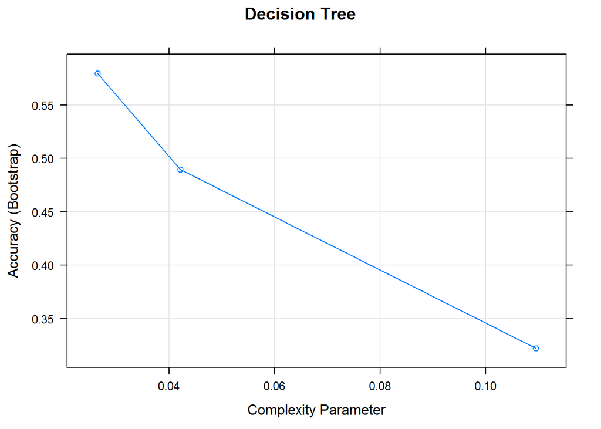

We can see that the decision tree does not seem to produce acceptable results, with an overall accuracy of only 55%.

##### Linear Discriminant Analysis

Next, we perform the same process using LDA, with the following results. We can easily see that, without any further tuning, LDA performs quite a bit better than the decision tree, with an accuracy of 71%.

```
## Confusion Matrix and Statistics
##
##           Reference
## Prediction   A   B   C   D   E
##          A 548  82  39  22  15
##          B  14 288  47  14  80
##          C  55  54 265  47  30
##          D  48  19  48 288  38
##          E   4  13  11  15 270
##
## Overall Statistics
##
##                Accuracy : 0.705
##                  95% CI : (0.686, 0.723)
##     No Information Rate : 0.284
##     P-Value [Acc > NIR] : <2e-16
##
##                   Kappa : 0.626
##  Mcnemar's Test P-Value : <2e-16
##
## Statistics by Class:
##
##                      Class: A Class: B Class: C Class: D Class: E
## Sensitivity             0.819    0.632    0.646    0.746    0.624
## Specificity             0.906    0.918    0.904    0.922    0.978
## Pos Pred Value          0.776    0.650    0.588    0.653    0.863
## Neg Pred Value          0.927    0.912    0.924    0.949    0.920
## Prevalence              0.284    0.194    0.174    0.164    0.184
## Detection Rate          0.233    0.122    0.113    0.122    0.115
## Detection Prevalence    0.300    0.188    0.192    0.187    0.133
## Balanced Accuracy       0.863    0.775    0.775    0.834    0.801
```

##### Random Forests

Our final model to test is random forests. Performance statistics are shown below.

```
## Confusion Matrix and Statistics
##
##           Reference
## Prediction   A   B   C   D   E
##          A 666  22   0   1   0
##          B   3 428  18   0   1
##          C   0   5 390  18   2
##          D   0   1   2 362   0
##          E   0   0   0   5 430
##
## Overall Statistics
##
##                Accuracy : 0.967
##                  95% CI : (0.959, 0.974)
##     No Information Rate : 0.284
##     P-Value [Acc > NIR] : <2e-16
##
##                   Kappa : 0.958
##  Mcnemar's Test P-Value : NA
##
## Statistics by Class:
##
##                      Class: A Class: B Class: C Class: D Class: E
## Sensitivity             0.996    0.939    0.951    0.938    0.993
## Specificity             0.986    0.988    0.987    0.998    0.997
## Pos Pred Value          0.967    0.951    0.940    0.992    0.989
## Neg Pred Value          0.998    0.985    0.990    0.988    0.998
## Prevalence              0.284    0.194    0.174    0.164    0.184
## Detection Rate          0.283    0.182    0.166    0.154    0.183
## Detection Prevalence    0.293    0.191    0.176    0.155    0.185
## Balanced Accuracy       0.991    0.964    0.969    0.968    0.995
```

At this point, random forests clearly outperforms the other models with an accuracy of 97%; therefore, we select the random forest model to continue refinement and training. The first thing we want to do is rebuild and validate the model using the entire training set. Again, the training portion of the data is set to 60% and the validation size is set to 40%. The new data sizes are shown below.

```
## [1] "Training set has  11776  examples."
```

```
## [1] "Validation set has  7846  examples."
```

Now, we rebuild the random forest model, this time using a 5-fold cross-validation process to get a better idea of how we can expect the model to perform on out-of-sample data. We also limit the number of trees to 300.

```
## [1] "The Random Forest Model:"
```

```
##
## Call:
##  randomForest(formula = classe ~ ., data = training, importance = TRUE,      ntree = 300, trainControl = tControl)
##                Type of random forest: classification
##                      Number of trees: 300
## No. of variables tried at each split: 7
##
##         OOB estimate of  error rate: 0.6%
## Confusion matrix:
##      A    B    C    D    E class.error
## A 3342    5    0    0    1    0.001792
## B   13 2259    7    0    0    0.008776
## C    0   15 2038    1    0    0.007790
## D    0    0   22 1906    2    0.012435
## E    0    0    1    4 2160    0.002309
```

```
## [1] "Performance on the validation set:"
```

```
## Confusion Matrix and Statistics
##
##           Reference
## Prediction    A    B    C    D    E
##          A 2228   22    0    0    0
##          B    4 1490   11    0    0
##          C    0    6 1354   24    1
##          D    0    0    3 1260    0
##          E    0    0    0    2 1441
##
## Overall Statistics
##
##                Accuracy : 0.991
##                  95% CI : (0.988, 0.993)
##     No Information Rate : 0.284
##     P-Value [Acc > NIR] : <2e-16
##
##                   Kappa : 0.988
##  Mcnemar's Test P-Value : NA
##
## Statistics by Class:
##
##                      Class: A Class: B Class: C Class: D Class: E
## Sensitivity             0.998    0.982    0.990    0.980    0.999
## Specificity             0.996    0.998    0.995    1.000    1.000
## Pos Pred Value          0.990    0.990    0.978    0.998    0.999
## Neg Pred Value          0.999    0.996    0.998    0.996    1.000
## Prevalence              0.284    0.193    0.174    0.164    0.184
## Detection Rate          0.284    0.190    0.173    0.161    0.184
## Detection Prevalence    0.287    0.192    0.177    0.161    0.184
## Balanced Accuracy       0.997    0.990    0.992    0.990    0.999
```

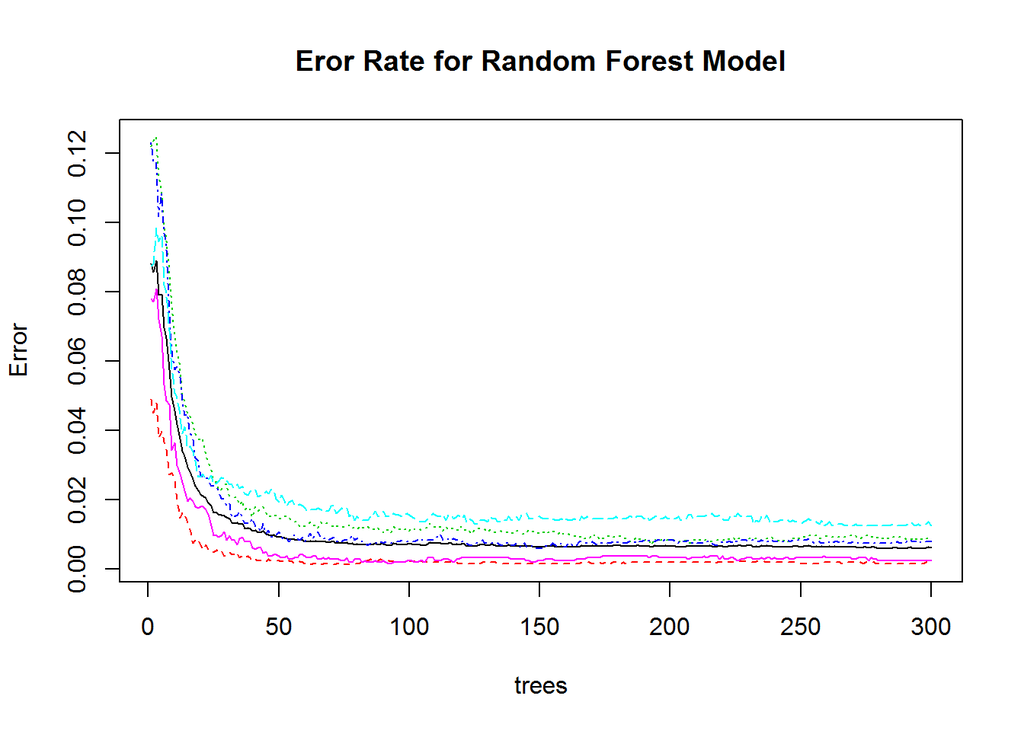

At this point, we want to do a little more exploration before accepting it as the final model. First, we want to see if it would be helpful to remove any of the predictors. We do this by running two tests: (1) checking for variables that have near-zero variance, and (2) looking at the relative importance of the variables to the model. Using the function, “nearZeroVar”, we obtain the following result:

```
## [1] "There are  0  predictors with near zero variance."
```

This is a good indicator that our predictor set is a solid one, but we will also look at the importance of the various predictors to the model (only the top 20 are plotted to improve visibility).

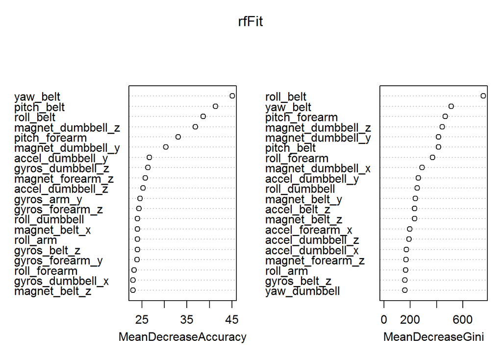

#### The Final Test

Now that we have a model that performs well on our validation set, it is time to try it on the final test set.

```
## [1] "The test predictions are: "
```

```
##  1  2  3  4  5  6  7  8  9 10 11 12 13 14 15 16 17 18 19 20
##  B  A  B  A  A  E  D  B  A  A  B  C  B  A  E  E  A  B  B  B
## Levels: A B C D E
```

These results were verified by the assignment submission to be 100% accurate, showing that the model was, indeed, a good fit for the data.